# Introduction to Python Project : FoodHub Data Analysis

### Problem Statement

The number of restaurants in New York is increasing day by day. Lots of students and busy professionals rely on those restaurants due to their hectic lifestyles. Online food delivery service is a great option for them. It provides them with good food from their favorite restaurants. A food aggregator company FoodHub offers access to multiple restaurants through a single smartphone app.

The app allows the restaurants to receive a direct online order from a customer. The app assigns a delivery person from the company to pick up the order after it is confirmed by the restaurant. The delivery person then uses the map to reach the restaurant and waits for the food package.

Once the food package is handed over to the delivery person, he/she confirms the pick-up in the app and travels to the customer's location to deliver the food. The delivery person confirms the drop-off in the app after delivering the food package to the customer. The customer can rate the order in the app. The food aggregator earns money by collecting a fixed margin of the delivery order from the restaurants.

### Objective

The food aggregator company has stored the data of the different orders made by the registered customers in their online portal. They want to analyze the data to get a fair idea about the demand of different restaurants which will help them in enhancing their customer experience. Suppose you are hired as a Data Scientist in this company and the Data Science team has shared some of the key questions that need to be answered. Perform the data analysis to find answers to these questions that will help the company to improve the business.

### Data Dictionary

- order_id: Unique ID of the order
- customer_id: ID of the customer who ordered the food
- restaurant_name: Name of the restaurant
- cuisine_type: Cuisine ordered by the customer
- cost_of_the_order: Price paid per order
- day_of_the_week: Indicates whether the order is placed on a weekday or weekend (The weekday is from Monday to Friday and the weekend is Saturday and Sunday)
- rating: Rating given by the customer out of 5
- food_preparation_time: Time (in minutes) taken by the restaurant to prepare the food. This is calculated by taking the difference between the timestamps of the restaurant's order confirmation and the delivery person's pick-up confirmation.
- delivery_time: Time (in minutes) taken by the delivery person to deliver the food package. This is calculated by taking the difference between the timestamps of the delivery person's pick-up confirmation and drop-off information

### Let us start by importing the required libraries

```python
# Libraries to help with reading and manipulating data
import pandas as pd
import numpy as np

# Libraries to help with data visualization
import matplotlib.pyplot as plt
import seaborn as sns
%matplotlib inline
```

### Understanding the structure of the data

```python
from google.colab import drive
drive.mount('/content/drive')
```

```python
df = pd.read_csv("/content/drive/MyDrive/Python/foodhub_order.csv")
```

```python
df.head()
```

|  | order_id | customer_id | restaurant_name | cuisine_type | cost_of_the_order | day_of_the_week | rating | food_preparation_time | delivery_time |
| --- | --- | --- | --- | --- | --- | --- | --- | --- | --- |
| 0 | 1477147 | 337525 | Hangawi | Korean | 30.75 | Weekend | Not given | 25 | 20 |
| 1 | 1477685 | 358141 | Blue Ribbon Sushi Izakaya | Japanese | 12.08 | Weekend | Not given | 25 | 23 |
| 2 | 1477070 | 66393 | Cafe Habana | Mexican | 12.23 | Weekday | 5 | 23 | 28 |
| 3 | 1477334 | 106968 | Blue Ribbon Fried Chicken | American | 29.20 | Weekend | 3 | 25 | 15 |
| 4 | 1478249 | 76942 | Dirty Bird to Go | American | 11.59 | Weekday | 4 | 25 | 24 |

### **Question 1:** How many rows and columns are present in the data? [0.5 mark]

```python
df.shape
```

```
(1898, 9)
```

#### Observations:

- The dataset has 1898 rows and 9 columns

### **Question 2:** What are the datatypes of the different columns in the dataset? (The info() function can be used) [0.5 mark]

```python
df.info()
```

```
<class 'pandas.core.frame.DataFrame'>
RangeIndex: 1898 entries, 0 to 1897
Data columns (total 9 columns):
 #   Column                 Non-Null Count  Dtype
---  ------                 --------------  -----
 0   order_id               1898 non-null   int64
 1   customer_id            1898 non-null   int64
 2   restaurant_name        1898 non-null   object
 3   cuisine_type           1898 non-null   object
 4   cost_of_the_order      1898 non-null   float64
 5   day_of_the_week        1898 non-null   object
 6   rating                 1898 non-null   object
 7   food_preparation_time  1898 non-null   int64
 8   delivery_time          1898 non-null   int64
dtypes: float64(1), int64(4), object(4)
memory usage: 133.6+ KB
```

#### Observations:

- All the columns have 1898 observations in which `rating` column constist of some 'not given' values it become needs to drop while operation in later stage
- The `rating` column is being read as a 'object' data type but it should be in integer data type
- The `restaurant name`, `cuisine type`, `day of the week` columns are of object type while the rest of the columns are numerical in nature
- The object type columns contain categories in them

### **Question 3:** Are there any missing values in the data? If yes, treat them using an appropriate method. [1 mark]

```python
df.isnull().sum()
```

```
order_id                 0
customer_id              0
restaurant_name          0
cuisine_type             0
cost_of_the_order        0
day_of_the_week          0
rating                   0
food_preparation_time    0
delivery_time            0
dtype: int64
```

```python
(df['rating'] == 'Not given').sum()
```

```
736
```

#### Observations:

- There are no missing values in FoodHub data
- But further reviwing the `rating` column we observe that some value contain as 'not given' value having count of 736 and this will be need to remove while performing further operation

### **Question 4:** Check the statistical summary of the data. What is the minimum, average, and maximum time it takes for food to be prepared once an order is placed? [2 marks]

```python
df.describe().T
```

|  | count | mean | std | min | 25% | 50% | 75% | max |
| --- | --- | --- | --- | --- | --- | --- | --- | --- |
| order_id | 1898.0 | 1.477496e+06 | 548.049724 | 1476547.00 | 1477021.25 | 1477495.50 | 1.477970e+06 | 1478444.00 |
| customer_id | 1898.0 | 1.711685e+05 | 113698.139743 | 1311.00 | 77787.75 | 128600.00 | 2.705250e+05 | 405334.00 |
| cost_of_the_order | 1898.0 | 1.649885e+01 | 7.483812 | 4.47 | 12.08 | 14.14 | 2.229750e+01 | 35.41 |
| food_preparation_time | 1898.0 | 2.737197e+01 | 4.632481 | 20.00 | 23.00 | 27.00 | 3.100000e+01 | 35.00 |
| delivery_time | 1898.0 | 2.416175e+01 | 4.972637 | 15.00 | 20.00 | 25.00 | 2.800000e+01 | 33.00 |

### **Question 5:** How many orders are not rated? [1 mark]

```python
(df["rating"]=="Not given").sum()
```

```
736
```

#### Observations:

- There are **736** orders not rated by customer.

### Exploratory Data Analysis (EDA)

### **Question 6:** Explore all the variables and provide observations on their distributions. (Generally, histograms, boxplots, countplots, etc. are used for univariate exploration.) [9 marks]

### Observation on **Cost of the order**

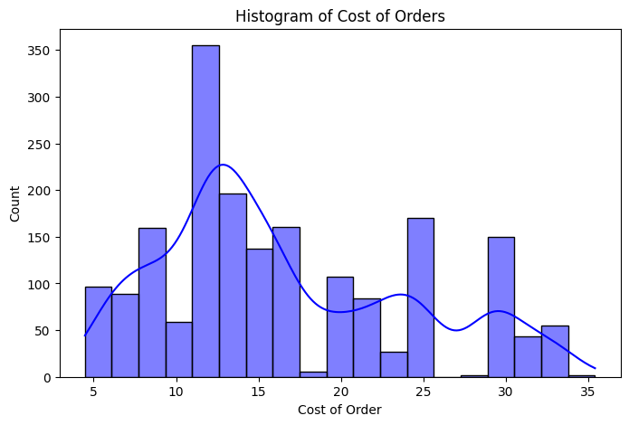

```python
#Histogram
plt.figure(figsize=(8, 5))
sns.histplot(data = df, x = "cost_of_the_order", color='b', kde = True)
plt.title('Histogram of Cost of Orders')
plt.xlabel('Cost of Order')
plt.ylabel('Count')
plt.show()
```

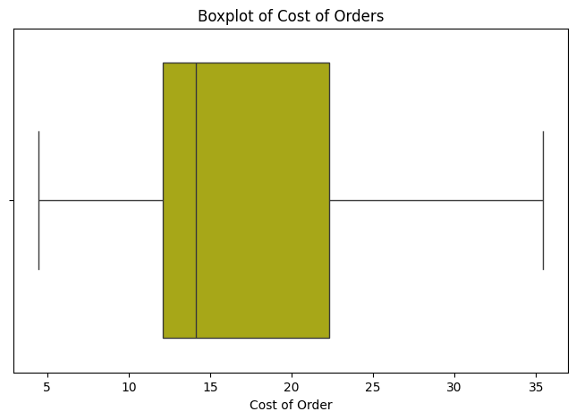

```python
#Boxplot
plt.figure(figsize=(8, 5))
sns.boxplot(data = df, x = "cost_of_the_order", color='y')
plt.title('Boxplot of Cost of Orders')
plt.xlabel('Cost of Order')
plt.show()
```

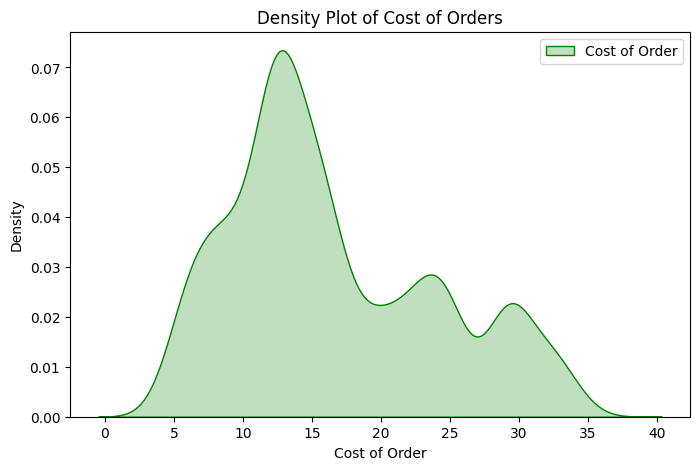

```python
#Density plot
plt.figure(figsize=(8, 5))
sns.kdeplot(df['cost_of_the_order'], shade=True, color='g', label='Cost of Order')
plt.title('Density Plot of Cost of Orders')
plt.xlabel('Cost of Order')
plt.ylabel('Density')
plt.legend()
plt.show()
```

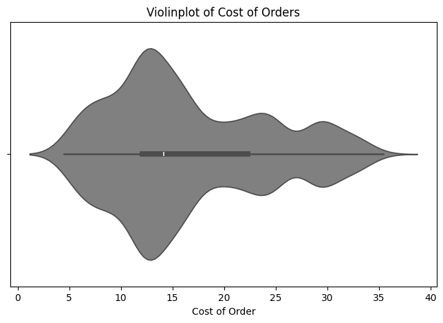

```python
#Violinplot
plt.figure(figsize=(8, 5))
sns.violinplot(data = df, x = "cost_of_the_order", color='Grey')
plt.title('Violinplot of Cost of Orders')
plt.xlabel('Cost of Order')
plt.show()
```

### Observation

- The minimum cost of the order is 4 dollars and maximum is 35 dollars

### Observation on **Rating**

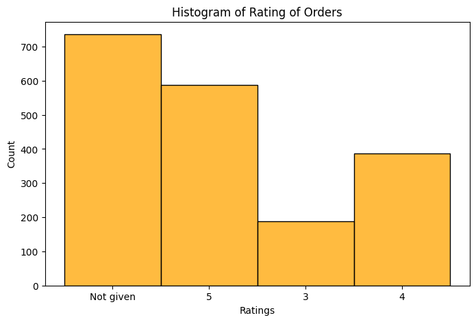

```python
#Histogram
plt.figure(figsize=(8, 5))
sns.histplot(data = df, x = "rating", color='Orange')
plt.title('Histogram of Rating of Orders')
plt.xlabel('Ratings')
plt.ylabel('Count')
plt.show()
```

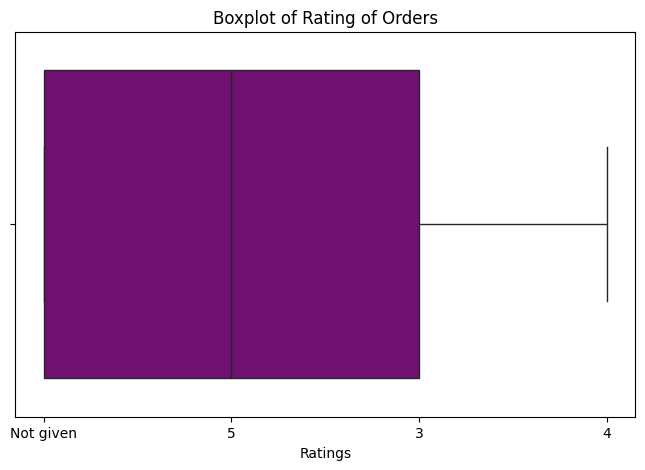

```python
#Boxplot
plt.figure(figsize=(8, 5))
sns.boxplot(data = df, x = "rating", color='Purple')
plt.title('Boxplot of Rating of Orders')
plt.xlabel('Ratings')
plt.show()
```

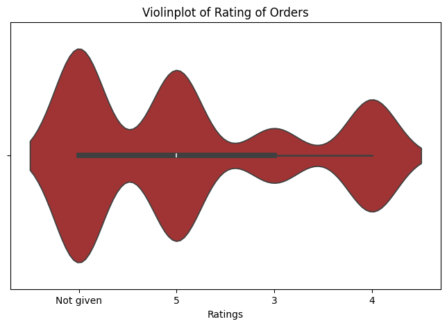

```python
#Violinplot
plt.figure(figsize=(8, 5))
sns.violinplot(data = df, x = "rating", color='firebrick')
plt.title('Violinplot of Rating of Orders')
plt.xlabel('Ratings')
plt.show()
```

### Observation on **Food preparation time**

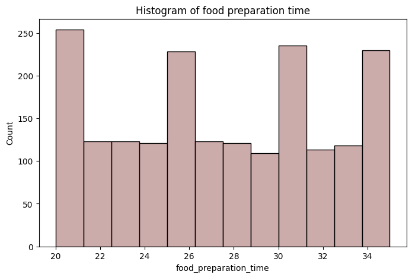

```python
#Histogram
plt.figure(figsize=(8, 5))
sns.histplot(data = df, x = "food_preparation_time", color='rosybrown')
plt.title('Histogram of food preparation time')
plt.xlabel('food_preparation_time')
plt.ylabel('Count')
plt.show()
```

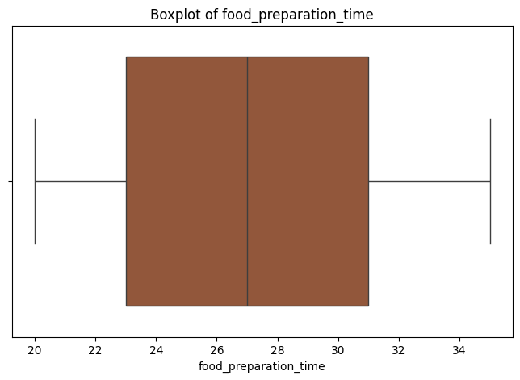

```python
#Boxplot
plt.figure(figsize=(8, 5))
sns.boxplot(data = df, x = "food_preparation_time", color='sienna')
plt.title('Boxplot of food_preparation_time')
plt.xlabel('food_preparation_time')
plt.show()
```

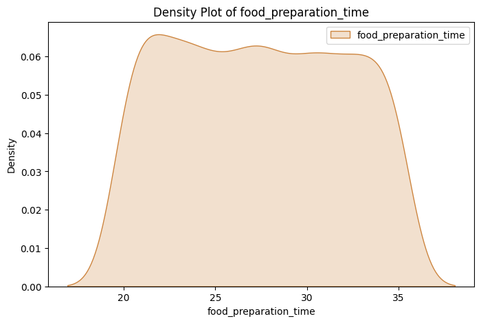

```python
#Density plot
plt.figure(figsize=(8, 5))
sns.kdeplot(df['food_preparation_time'], shade=True, color='peru', label='food_preparation_time')
plt.title('Density Plot of food_preparation_time')
plt.xlabel('food_preparation_time')
plt.ylabel('Density')
plt.legend()
plt.show()
```

### Observation

- When order is confirmed by restaurant, the minimum food preparation time is 20 min and maximum is 35 min

### Observation on **Delivery_time**

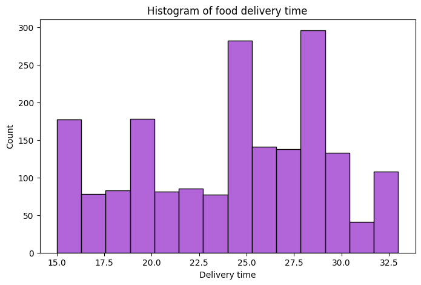

```python
#Histogram
plt.figure(figsize = (8, 5))
sns.histplot(data = df, x = "delivery_time", color = 'darkorchid')
plt.title('Histogram of food delivery time')
plt.xlabel('Delivery time')
plt.ylabel('Count')
plt.show()
```

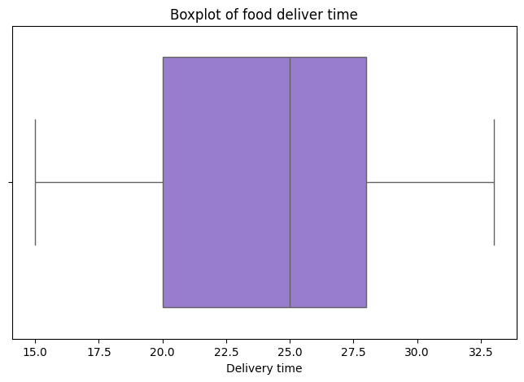

```python
#Boxplot
plt.figure(figsize = (8, 5))
sns.boxplot(data = df, x = "delivery_time", color = 'mediumpurple')
plt.title('Boxplot of food deliver time')
plt.xlabel('Delivery time')
plt.show()
```

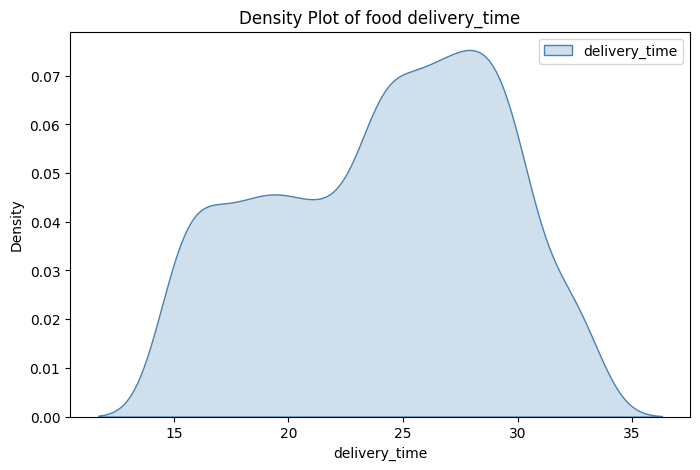

```python
#Density plot
plt.figure(figsize=(8, 5))
sns.kdeplot(df['delivery_time'], shade=True, color='steelblue', label='delivery_time')
plt.title('Density Plot of food delivery_time')
plt.xlabel('delivery_time')
plt.ylabel('Density')
plt.legend()
plt.show()
```

### Observation

- The minimum waiting time for customers once food is prepared is 15 min as well as maximum is 33 min

### Observation on **Cuisine type**

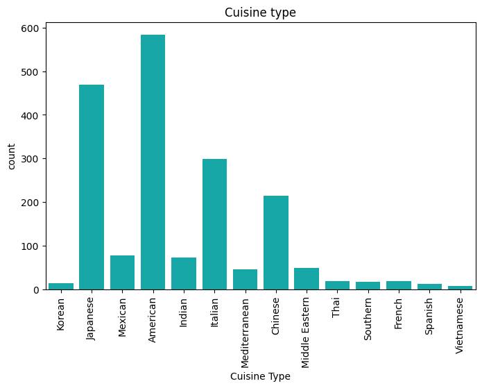

```python
#Countplot
plt.figure(figsize=(8,5))
sns.countplot(data = df, x = "cuisine_type", color = 'c')
plt.title('Cuisine type')
plt.xlabel('Cuisine Type')
plt.xticks(rotation = 90)
plt.show()
```

### Observation on **Day of the week**

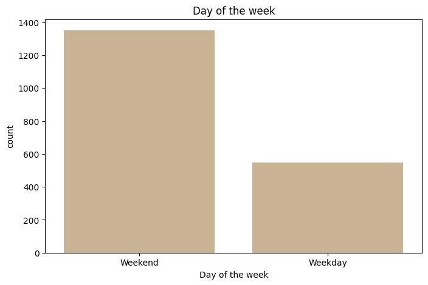

```python
#Count plot
plt.figure(figsize=(8,5))
sns.countplot(data = df, x = "day_of_the_week", color = 'tan')
plt.title('Day of the week')
plt.xlabel('Day of the week')
plt.show()
```

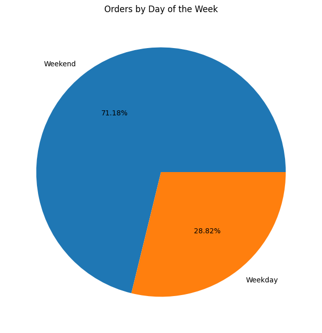

```python
#Pie chart
#Total number of days
day_counts = df['day_of_the_week'].value_counts()

# Plot a pie chart
plt.figure(figsize=(8, 8))
plt.pie(day_counts, labels=day_counts.index, autopct='%1.2f%%')
plt.title('Orders by Day of the Week')
plt.show()
```

### Observation

- Most of the orders are placed on weekend

### Observation on **Restaurant name**

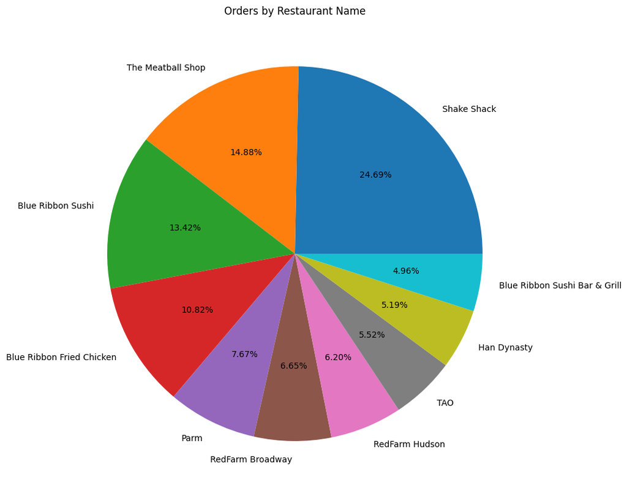

```python
#Pie chart
#Total number of restaurants
restaurant_counts = df['restaurant_name'].value_counts().nlargest(10)

# Plot a pie chart
plt.figure(figsize=(10, 10))
plt.pie(restaurant_counts, labels=restaurant_counts.index, autopct='%1.2f%%')
plt.title('Orders by Restaurant Name')
plt.show()
```

### Observation

- Above restaurants are important to company to increase the profit.

### **Question 7**: Which are the top 5 restaurants in terms of the number of orders received? [1 mark]

```python
top_5_restaurants = df["restaurant_name"].value_counts().head()
top_5_restaurants
```

```
restaurant_name
Shake Shack                  219
The Meatball Shop            132
Blue Ribbon Sushi            119
Blue Ribbon Fried Chicken     96
Parm                          68
Name: count, dtype: int64
```

#### Observations:

- `Shake Shack`, `The Meatball Shop`, `Blue Ribbon Sushi`, `Blue Ribbon Fried Chicken` and `Parm` these are top 5 restaurants by considering number of orders received from customer

### **Question 8**: Which is the most popular cuisine on weekends? [1 mark]

```python
df.groupby("day_of_the_week")["cuisine_type"].value_counts()
```

```
day_of_the_week  cuisine_type
Weekday          American          169
                 Japanese          135
                 Italian            91
                 Chinese            52
                 Mexican            24
                 Indian             24
                 Middle Eastern     17
                 Mediterranean      14
                 Southern            6
                 French              5
                 Thai                4
                 Vietnamese          3
                 Korean              2
                 Spanish             1
Weekend          American          415
                 Japanese          335
                 Italian           207
                 Chinese           163
                 Mexican            53
                 Indian             49
                 Middle Eastern     32
                 Mediterranean      32
                 Thai               15
                 French             13
                 Korean             11
                 Southern           11
                 Spanish            11
                 Vietnamese          4
Name: count, dtype: int64
```

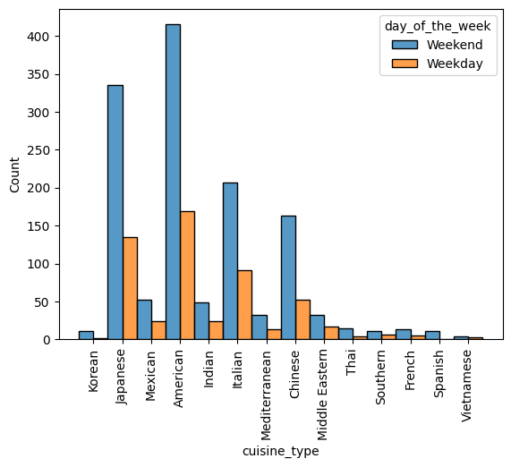

```python
sns.histplot(data = df, x = "cuisine_type", hue = "day_of_the_week", multiple="dodge")
plt.xticks(rotation = 90)
plt.show()
```

#### Observations:

- Most popular cuisine on weekend is `American`.

### **Question 9**: What percentage of the orders cost more than 20 dollars? [2 marks]

```python
#total number of orders
total_orders = len(df["cost_of_the_order"])
total_orders

#total number of orders which are cost more than 20 dollars
order_above_20 = (df["cost_of_the_order"] > 20)
num_order_above_20 = order_above_20.value_counts()
num_order_above_20

#percentage of orders that cost more than 20 dollars
percentage_above_20 = ((num_order_above_20 / total_orders) * 100).round(2)
percentage_above_20
```

```
cost_of_the_order
False    70.76
True     29.24
Name: count, dtype: float64
```

#### Observations:

- There are **29.24 %** order cost more than 20 dollars.

### **Question 10**: What is the mean order delivery time? [1 mark]

```python
df["delivery_time"].mean().round(2)
```

```
24.16
```

#### Observations:

- The mean order delivery time is **24.16 minutes**.

### **Question 11:** The company has decided to give 20% discount vouchers to the top 3 most frequent customers. Find the IDs of these customers and the number of orders they placed. [1 mark]

```python
top_customer = (df.groupby("customer_id")["order_id"].count()).sort_values(ascending = False).head(3)
top_customer
```

```
customer_id
52832    13
47440    10
83287     9
Name: order_id, dtype: int64
```

#### Observations:

- The lucky customer id's who receive 20% discount vouchers are 52832, 47440, 83287 and upto date they placed orders 13, 10, 9 respectively

### **Question 12**: Perform a multivariate analysis to explore relationships between the important variables in the dataset. (It is a good idea to explore relations between numerical variables as well as relations between numerical and categorical variables) [10 marks]